# Tölvuverkefni 3

Ásmundur Óskar Ásmundsson (aoa27@hi.is) og Helgi Sigtryggsson (hes86@hi.is)

## a) liður

Byrjum á því að lesa gögninn inn og setjum þau í gagnaramma sem við köllum ah.

```r
ah <- read.csv("data98.csv", sep = ",")
```

Búum nú til tvær nýjar breytur og látum báðar vera flokkabreytur. Búum fyrst til flokkabreytuna hafsvaedi sem hefur gildin “SV”, “SA”, “NV” eða “NAu” og hvert svæði er skilgreint út frá lengdar- og breiddargráðu sem við sækjum úr breytunni reit, þ.e. ef svæði hefur breiddargráðu minnni en 65 þá erum við fyrir sunnan annars fyrir norðan og ef svæði hefur lengdargráðu minni en -19 þá erum við fyrir vestan annars fyrir austan. Síðan búum við til flokkabreytuna kt2 sem segir til um hvort fiskur sé kynþroska eða ókynþroska.

```r
r2d <-
function(r)
{
    lat <- floor(r/100)
    lon <- (r - lat * 100) %% 50
    halfb <- (r - 100 * lat - lon)/100
    lon <-  - (lon + 0.5)
    lat <- lat + 60 + halfb + 0.25
    data.frame(lat = lat, lon = lon)
}

latitude<- r2d(ah$reit)$lat
longtitude <- r2d(ah$reit)$lon

hafsvaedi <- ifelse(
               latitude < 65,
               ifelse(longtitude < -19, "SV", "SA"),
               ifelse(longtitude < -19, "NV", "NAu")
             )

kt2 <- ifelse(ah$kt == 1, "Ókynþroska", "Kynþroska")

ah <- ah %>%
  mutate(
    hafsvaedi = factor(hafsvaedi),
    kt2 = factor(kt2)
  )
```

## b) liður

Fáum töflu sem sýnir fjölda fiska af hvoru kynþroskastigi eftir hafsvæðum.

```r
taflab <- ah %>%
  group_by("Hafsvæði" = hafsvaedi) %>%
  summarise(
    "Kynþroska" = sum(kt2 == "Kynþroska"),
    "Ókynþroska" = sum(kt2 == "Ókynþroska")
  )

taflab %>%
  kable(align = "lll", caption = "Tafla 1: Fjöldi fiska af hvoru kynþroskastigi eftir hafsvæðum") %>%
  kable_styling(position = "center")
```

Tafla 1: Fjöldi fiska af hvoru kynþroskastigi eftir hafsvæðum

| Hafsvæði | Kynþroska | Ókynþroska |
| --- | --- | --- |
| NAu | 215 | 981 |
| NV | 394 | 934 |
| SA | 224 | 204 |
| SV | 508 | 221 |

Búum svo til aðra töflu þar sem við bætum við kynþroskahlutfalli á hverju hafsvæði.

```r
t <- table("Hafsvæði" = ah$hafsvaedi, ah$kt2)
prop.table(t, margin = 1) %>%
  kable(align = "lll", caption = "Tafla 2: Fjöldi og hlutfall fiska af hvoru kynþroskastigi eftir hafsvæðum") %>%
  kable_styling(position = "center")
```

Tafla 2: Fjöldi og hlutfall fiska af hvoru kynþroskastigi eftir hafsvæðum

|  | Kynþroska | Ókynþroska |
| --- | --- | --- |
| NAu | 0.1797659 | 0.8202341 |
| NV | 0.2966867 | 0.7033133 |
| SA | 0.5233645 | 0.4766355 |
| SV | 0.6968450 | 0.3031550 |

Teiknum loks mynd sem sýnir fjölda fiska af hvoru kynþroskastigi í hverjum flokki af hafsvæðunum fjórum.

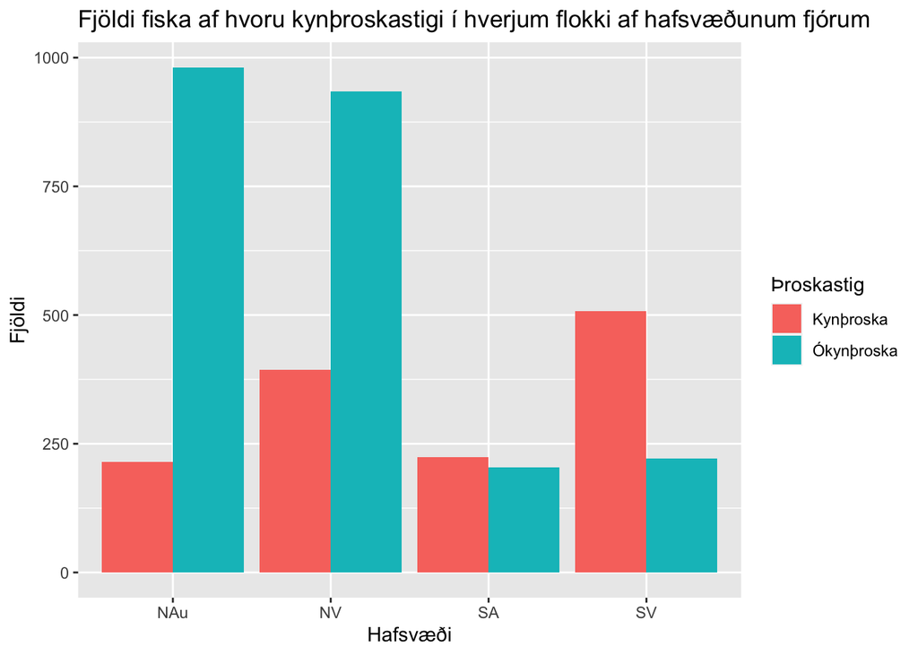

```r
ggplot(ah, aes(hafsvaedi, fill = kt2)) +
  geom_bar(position = 'dodge') +
  labs(
    title = "Fjöldi fiska af hvoru kynþroskastigi í hverjum flokki af hafsvæðunum fjórum",
    x = "Hafsvæði",
    y = "Fjöldi",
    fill = "Þroskastig"
  )
```

## c) liður

Sýnum töflu með fjölda fiska, meðallengd, meðalþyngd og staðalfrávik lengdar þeirra eftir aldri.

```r
taflac <- ah %>%
  group_by("Aldur" = aldur) %>%
  summarise(
    "Fjöldi fiska" = length(aldur),
    "Meðallengd" = mean(le),
    "Meðalþyngd" = mean(osl),
    "Staðalfrávik lengdar" = sd(le)
  )

taflac %>%
  kable(align = "lllll", caption = "Tafla 3: Tafla sem sýnir fjölda fiska, meðallengd, meðalþyngd og staðalfrávik lengdar eftir aldri") %>%
  kable_styling(position = "center")
```

Tafla 3: Tafla sem sýnir fjölda fiska, meðallengd, meðalþyngd og staðalfrávik lengdar eftir aldri

| Aldur | Fjöldi fiska | Meðallengd | Meðalþyngd | Staðalfrávik lengdar |
| --- | --- | --- | --- | --- |
| 1 | 3 | 22.66667 | 102.0000 | 2.081666 |
| 2 | 76 | 26.30263 | 165.5395 | 3.723868 |
| 3 | 632 | 38.55063 | 529.3180 | 5.277765 |
| 4 | 367 | 51.26158 | 1339.2316 | 7.902564 |
| 5 | 1211 | 61.44426 | 2132.9744 | 6.819454 |
| 6 | 750 | 71.43333 | 3424.9480 | 8.701102 |
| 7 | 262 | 79.19466 | 4767.2710 | 8.877858 |
| 8 | 209 | 85.25837 | 6407.2871 | 9.991354 |
| 9 | 135 | 88.51852 | 7266.0667 | 9.816109 |
| 10 | 27 | 93.85185 | 9392.5185 | 12.877242 |
| 11 | 6 | 93.66667 | 10665.3333 | 24.311863 |
| 13 | 1 | 132.00000 | 28282.0000 | NA |
| 14 | 1 | 145.00000 | 34484.0000 | NA |
| 15 | 1 | 110.00000 | 12750.0000 | NA |

Úr töflunni má lesa að flestir fiskar eru þriggja til sex ára. Fáir fiskar eru yngri en þriggja ára og fiskum eldri en sex ára fer hratt minnkandi. Þá eykst lengd og þyngd fiskanna með hækkandi aldri og dreifnin á gildi lengda verður meiri með hækkandi aldri en fyrir þá aldurshópa þar sem einungis er einn fiskur gefur R upp staðalfrávikið sem NA gildi. Þá þyngjast fiskarnir með hækkandi aldri.

Teiknum næst mynd sem sýnir lengd fiska eftir aldri þegar litið er á aldur sem samfellda breytu ásamt meðallengd fiska fyrir hvern aldurshóp sem stærri rauða punkta.

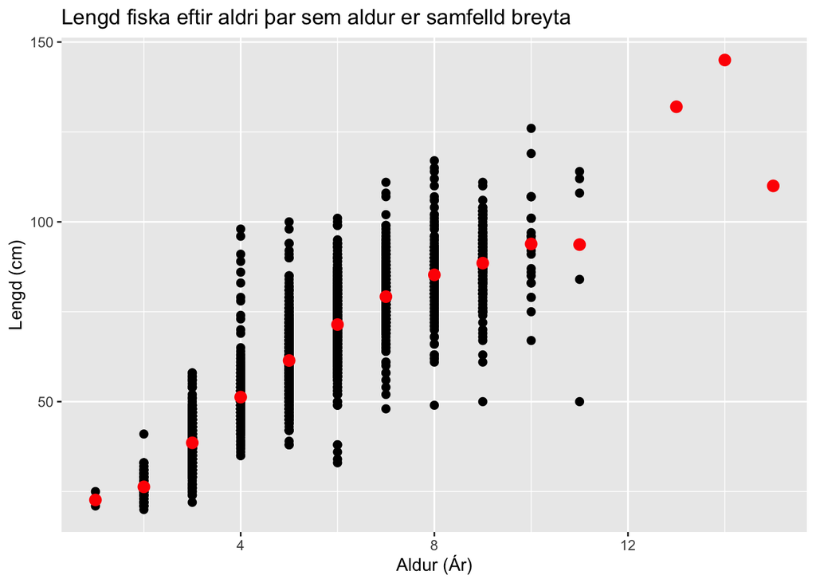

```r
ggplot(ah, aes(x = aldur, y = le)) +
  labs(
    title = "Lengd fiska eftir aldri þar sem aldur er samfelld breyta",
    x = "Aldur (Ár)",
    y = "Lengd (cm)"
  ) +
  geom_point(color = 1, size = 2) +
  geom_point(aes(x = Aldur, y = Meðallengd), taflac, color = 2, size = 3)
```

Teiknum svo einnig kassarit sem sýnir lengd fiska eftir aldri þegar litið er á aldur sem strjála breytu.

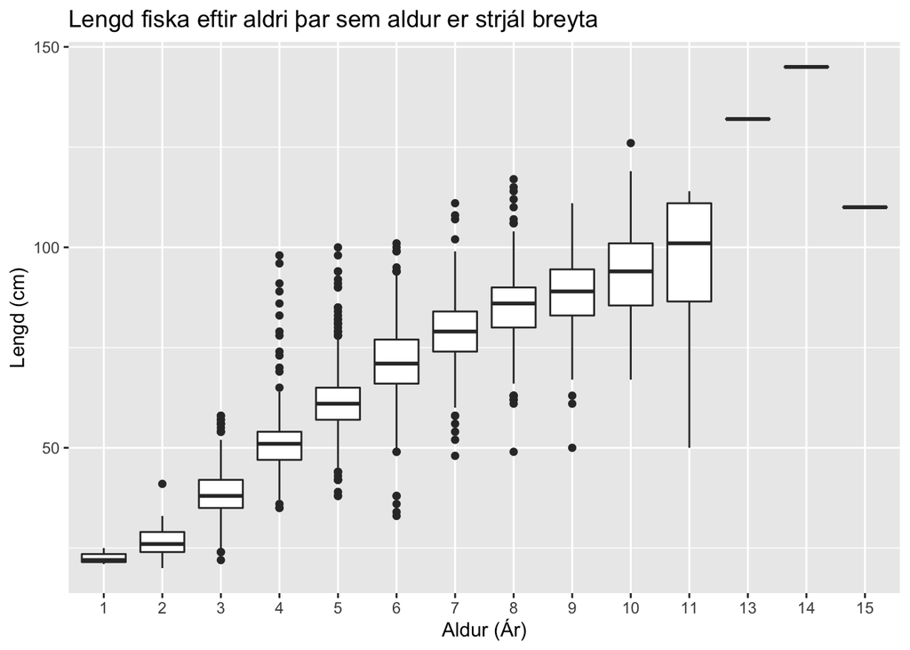

```r
ggplot(ah, aes(x = factor(aldur), y = le)) +
  labs(
    title = "Lengd fiska eftir aldri þar sem aldur er strjál breyta",
    x = "Aldur (Ár)",
    y = "Lengd (cm)"
  ) +
  geom_boxplot()
```

Nokkuð er um útlaga og þá sérstaklega í aldurshópununm fyrir miðju kassaritsins þ.e. meðal þriggja til átta ára fiska. Kassarit hentar vel til að bera kennsl á útlaga og meta dreifingu gagna. Kassarit geta hentað vel þegar setja á fram gagnasöfn þar sem mikið af gildum eru í hverjum flokki myndrænt því þau sýna ekki alla gagnapunkta heldur leggja áherslu á hver dreifing gagnanna er þess í stað. Framsetningin að ofan þar sem litið var á aldur sem samfellda breytu hefur einnig kosti þó erfiðara sé að greina útlaga á þeirri mynd því þar eru leitast við að sýna alla gagnapunkta. Sú mynd gefur skýrari niðurstöður fyrir þá flokka sem innihalda tiltölulega fáa gagnapunkta og kann að henta betur fyrir gagnasöfn þar sem hver flokkur hefur tiltölulega fáa gagnapunkta.

## d) liður

Veljum tvö hafsvæði með því að keyra eftirfarandi kóða sem velur tvö hafsvæði af hafsvæðunum fjórum af handahófi.

```r
set.seed(3110)
(svaedi <- sample(unique(hafsvaedi),2))
```

[output not shown]

Veljum nú af handahófi 50 fiska af hvoru hafsvæði og sameinum svo fiskana í einn gagnaramma.

```r
hafsvaedi1 <- filter(ah, hafsvaedi == "NV")
hafsvaedi2 <- filter(ah, hafsvaedi == "NAu")

set.seed(3110)
fiskar1 <- sample_n(hafsvaedi1, 50, replace = F)

set.seed(3110)
fiskar2 <- sample_n(hafsvaedi2, 50, replace = F)

fiskar <- rbind(fiskar1, fiskar2)
```

## e) liður

Við athugum nú hvort marktækur munur sé á meðallengd fiska á hafsvæðunum tveimur, $\mu_{NV}$ og $\mu_{NAu}$. Ef marktækur munur er á meðallengd fiska á hafsvæðunum tveimur myndum við þurfa að hafna núlltilgátunni í tilgátuprófinu:

$$H_{0}: \mu_{NV} - \mu_{NAu} = 0\\
H_{1}: \mu_{NV} - \mu_{NAu} \neq 0$$

Forsendur fyrir því að tilgátuprófið gefi heilvita niðurstöðu er að gögnin séu normaldreifð og meðallengd fiska sé óháð hafsvæði. Framkvæmum nú t-próf með tvíhliða gagntilgátu og marktæknikröfu $1-\alpha = 0.95$.

```r
tilgatuprofe <- t.test(fiskar$le ~ fiskar$hafsvaedi)
tilgatuprofe
```

```
##
##  Welch Two Sample t-test
##
## data:  fiskar$le by fiskar$hafsvaedi
## t = -2.7566, df = 97.965, p-value = 0.006967
## alternative hypothesis: true difference in means is not equal to 0
## 95 percent confidence interval:
##  -16.132718  -2.627282
## sample estimates:
## mean in group NAu  mean in group NV
##             53.92             63.30
```

```r
t0 <- tilgatuprofe$statistic
```

## f) liður

Meðal forsenda fyrir því að tilgátuprófið að ofan (sjá e-lið) gefi heilvita niðurstöðu var að gögnin væru normaldreifð. Nú viljum við kanna að hvort sú forsenda eigi rétt á sér þ.e. hvort gögnin fylgi normaldreifingu. Teiknum stuðlarit af lengd fyrir hvert hafsvæði og teiknum inn á stuðlaritin (í rauðum lit) þéttleikafall þeirrar normaldreifingar sem eðlilegt væri að búast við að gögnin fyrir hvert hafsvæði fylgdu.

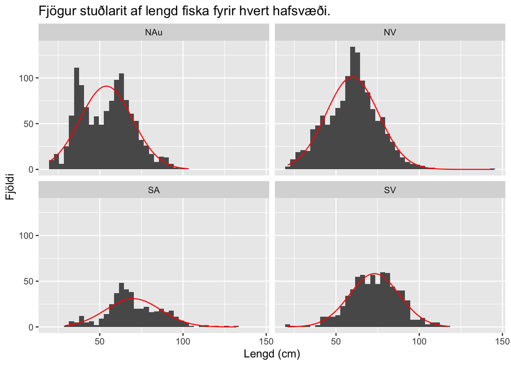

```r
# Skilgreinum fall sem ad tekur inn gagnavigur x og
#   skilar gognum sem fylgja "natturulegu" normaldreifingu vigursins x
get_normal_density <- function(x, binwidth) {
  grid <- seq(min(x), max(x), length=100)
  data.frame(
    le = grid,
    normal_curve = dnorm(grid, mean(x), sd(x)) * length(x) * binwidth
  )
}

# Skilgreinum breytu fyrir binwidth
BW <- 3

# Buum til normaldreifd gogn fyrir hvert hafsvaedi med thvi ad
#   beita fallinu "get_normal_density" a lengdarmaelingar sem tilheyra
#   hverju hafsvaedi fyrir sig
normaldens <-
  ah %>%
  group_by(hafsvaedi) %>%
  do(get_normal_density(x = .$le, binwidth = BW))

#Teiknum nú upp myndirnar fjórar ásamt tilsvarandi þéttleikaföllum
ah_long = melt(ah, id.vars = 'hafsvaedi', measure.vars = 'le', value.name = 'le')

ggplot(ah_long, aes(le)) +
  geom_histogram(binwidth = 3) +
  geom_line(data = normaldens, aes(x = le, y = normal_curve), color = "red") +
  facet_wrap(vars(hafsvaedi)) +
  labs(
    title = "Fjögur stuðlarit af lengd fiska fyrir hvert hafsvæði.",
    x = "Lengd (cm)",
    y = "Fjöldi"
  )
```

Af stuðlaritunum fjórum sjáum við að hafsvæðin NV og SV eru nær því að vera normaldreifð en hafsvæðin NAu og SA sem þó falla nokkuð vel að normaldreifingu.

## g) liður

```r
#Finnum ný t-gildi
xyind <- c(rep(1,50), rep(2,50))
g <- replicate(5000, t.test(fiskar$le[sample(1:length(fiskar$le))] ~ xyind)$statistic)
#Teljum hve oft nýja t-gildið er tölulega stærra en upphaflega t-gildið
count <- 0
for (i in 1:5000)
  if(g[i] > t0)
    count <- count + 1
#Finnum p-gildi prófsins
p <- count/5000
p
```

```
## [1] 0.9964
```

## h) liður

Eftirfarandi tafla sýnir fjölda kynþroska og ókynþroska fiska á hvoru hafsvæði

```r
fiskar$hafsvaedi <- droplevels(fiskar$hafsvaedi)

taflah <- fiskar %>%
  group_by("Hafsvæði" = hafsvaedi) %>%
  summarise(
    "Kynþroska" = sum(kt2 == "Kynþroska"),
    "Ókynþroska" = sum(kt2 == "Ókynþroska")
  )
taflah %>%
  kable(align = "lll", caption = "Tafla 4: Tafla yfir fjölda kynþroska og ókynþroska fiska á hvoru hafsvæði.") %>%
  kable_styling(position = "center")
```

Tafla 4: Tafla yfir fjölda kynþroska og ókynþroska fiska á hvoru hafsvæði.

| Hafsvæði | Kynþroska | Ókynþroska |
| --- | --- | --- |
| NAu | 12 | 38 |
| NV | 21 | 29 |

Við athugum nú hvort marktækur munur sé á hlutfalli kynþroska fiska á hafsvæðunum tveimur, $p_{NV}$ og $p_{NAu}$. Ef marktækur munur er á hlutfalli kynþroska fiska á hafsvæðunum tveimur myndum við þurfa að hafna núlltilgátunni í tilgátuprófinu:

$$H_{0}: p_{NV} = p_{NAu}\\
H_{1}: p_{NV} \neq p_{NAu}$$

Framkvæmum nú próf fyrir $p$ í tvíkostadreifingu með tvíhliða gagntilgátu og marktæknikröfu $1-\alpha = 0.95$.

```r
tilgatuprofh <- prop.test(table(fiskar$hafsvaedi, fiskar$kt2))
tilgatuprofh
```

```
##
##  2-sample test for equality of proportions with continuity correction
##
## data:  table(fiskar$hafsvaedi, fiskar$kt2)
## X-squared = 2.8946, df = 1, p-value = 0.08888
## alternative hypothesis: two.sided
## 95 percent confidence interval:
##  -0.38091221  0.02091221
## sample estimates:
## prop 1 prop 2
##   0.24   0.42
```

## i) liður

Teiknum mynd sem sýnir sambandið milli lengdar og þyngdar fiskanna á hafsvæðinu NV.

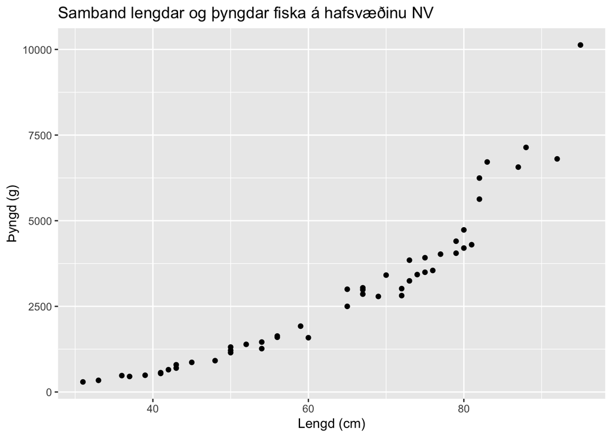

```r
#Veljum annað hafsvæðanna úr e-lið, hér veljum við hafsvæðið NV
ggplot(fiskar1, aes(x = le, y = osl)) +
  geom_point() +
  labs(
    title = "Samband lengdar og þyngdar fiska á hafsvæðinu NV",
    x = "Lengd (cm)",
    y = "Þyngd (g)"
  )
```

Við sjáum að þyngd vex með lengd og virðast fylgja vísisveldisvexti. Við getum því ályktað að þyngd aukist í hlutfalli við veldi af lengd þ.e. að til séu fastar $\alpha$ og $c$ þannig að $w = \alpha l^{c}$ þar sem $w$ er þyngd og $l$ er lengd. Það er því eðlilegt að líta á stærðirnar á log-log grafi og fá þannig línulegt samband $ln(w) = cln(l)+ln(\alpha)$.

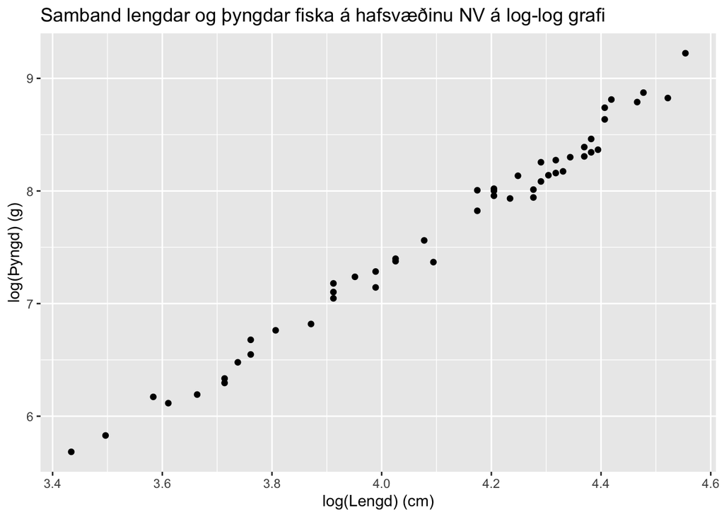

```r
#Teiknum einnig mynd sem sýnir samband stærðanna á log-log grafi
ggplot(fiskar1, aes(x = log(le), y = log(osl))) +
  geom_point() +
  labs(
    title = "Samband lengdar og þyngdar fiska á hafsvæðinu NV á log-log grafi",
    x = "log(Lengd) (cm)",
    y = "log(Þyngd) (g)"
  )
```

Við sjáum nú að á log-log grafi er línulegt samband milli stærðanna þ.e. logri þyngdar vex línulega sem fall af logra lengdar. Smíðum nú línulegt aðhvarfsgreiningarlíkan að punktunum en þá er eðlilegra að nota logrann af báðum breytum þar sem þær stærðir virðast fylgja nokkurn veginn línulegu sambandi.

```r
fit <- lm(log(osl) ~ log(le), data = fiskar1)
summary(fit)
```

```
##
## Call:
## lm(formula = log(osl) ~ log(le), data = fiskar1)
##
## Residuals:
##       Min        1Q    Median        3Q       Max
## -0.223110 -0.093258  0.000306  0.075067  0.235253
##
## Coefficients:
##             Estimate Std. Error t value Pr(>|t|)
## (Intercept) -4.85158    0.22134  -21.92   <2e-16 ***
## log(le)      3.03908    0.05375   56.54   <2e-16 ***
## ---
## Signif. codes:  0 '***' 0.001 '**' 0.01 '*' 0.05 '.' 0.1 ' ' 1
##
## Residual standard error: 0.1111 on 48 degrees of freedom
## Multiple R-squared:  0.9852, Adjusted R-squared:  0.9849
## F-statistic:  3197 on 1 and 48 DF,  p-value: < 2.2e-16
```

## j) liður

Teiknum inn á myndina sem sýnir samband milli lengdar og þyngdar fiskanna bestu beinu línu ásamt bestu línu sem líkanið sem smíðað var í i-lið gefur (í rauðu).

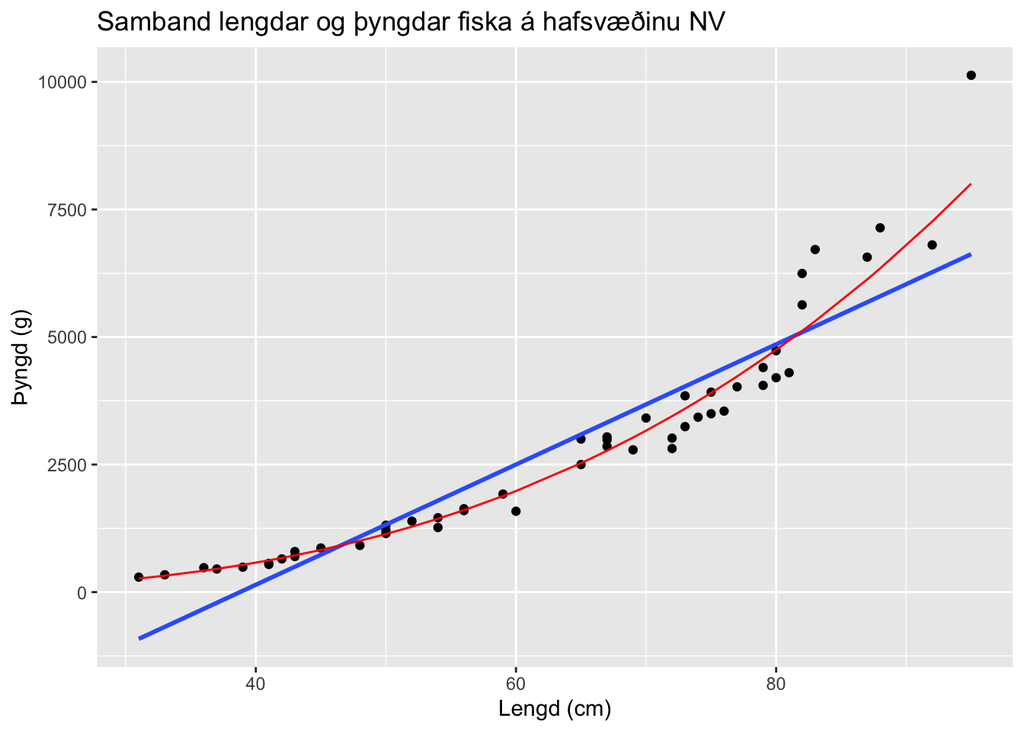

```r
#Búum til nýjan gagnaramma sem inniheldur spábreytugildin úr líkaninu og gildi háðu breytunnar úr líkaninu
gogn_likan <-
  data.frame(
    x = exp(fit$model[['log(le)']]),
    y = exp(predict(fit))
  )
#Teiknum síðan myndina ásamt línunum sem við höfum áhuga á
ggplot(fiskar1, aes(x = le, y = osl)) +
  geom_point() +
  labs(
    title = "Samband lengdar og þyngdar fiska á hafsvæðinu NV",
    x = "Lengd (cm)",
    y = "Þyngd (g)"
  ) +
  stat_smooth(method = 'lm', se = FALSE) +
  geom_line(data = gogn_likan, aes(x, y), color = "red")
```

## k) liður

Teiknum kasssarit sem sýnir lengd á móti aldri fyrir hafsvæðið NV

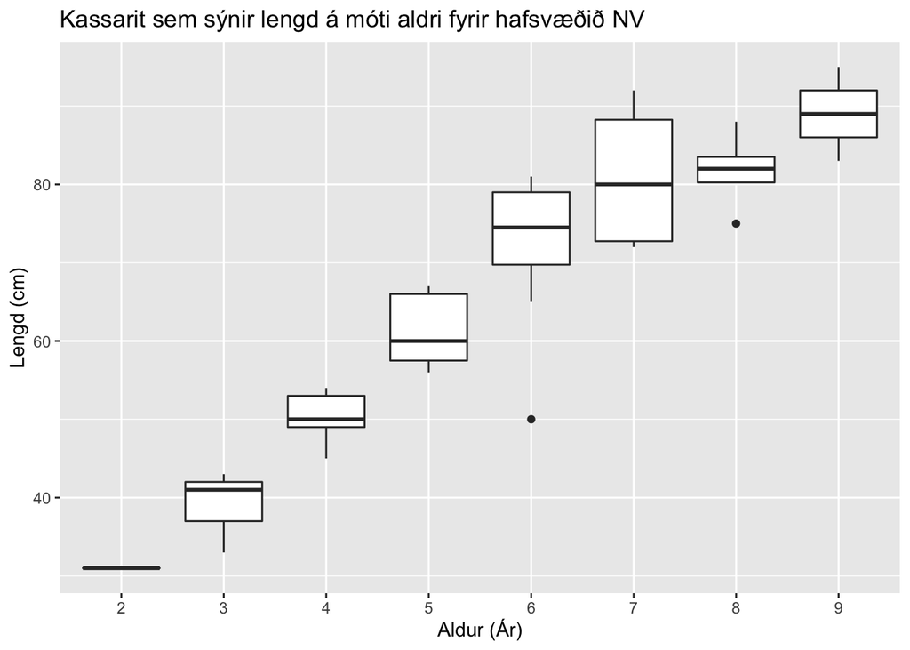

```r
#Teiknum kasssarit sem sýnir lengd á móti aldri
ggplot(data = fiskar1, aes(x = factor(aldur), y = le)) +
  geom_boxplot() +
  labs(
    title = "Kassarit sem sýnir lengd á móti aldri fyrir hafsvæðið NV",
    x = "Aldur (Ár)",
    y = "Lengd (cm)"
  )
```

Smíðum nú tvenn líkön. Annars vegar líkan sem leggur beina línu í gegnum gögnin og síðan frjálst líkan með aldurinn sem flokkabreytu.

```r
litid <- lm(le ~ aldur, data = fiskar1)
stort <- lm(le ~ factor(aldur), data = fiskar1)
anova(litid, stort)
```

```
## Analysis of Variance Table
##
## Model 1: le ~ aldur
## Model 2: le ~ factor(aldur)
##   Res.Df    RSS Df Sum of Sq      F  Pr(>F)
## 1     48 2240.2
## 2     42 1679.3  6    560.81 2.3376 0.04884 *
## ---
## Signif. codes:  0 '***' 0.001 '**' 0.01 '*' 0.05 '.' 0.1 ' ' 1
```

## Bónusspurning

Nú munum við teikna mynd af Íslandi. Sækjum fyrst gögn fyrir útlínur Íslands og útlínur fyrir dýpt á hafsvæðum og teiknum mynd af Íslandi ásamt dýptarlínum.

```r
Iceland <- map_data("world", region = "Iceland")

xlim <- c(-28, -10)
ylim <- c(62.5, 67.5)

depth <-
  getNOAA.bathy(
    lon1 = xlim[1], lon2 = xlim[2],
    lat1 = ylim[1], lat2 = ylim[2],
    resolution = 1
  ) %>%
  fortify()

kort <- ggplot() +
  geom_contour(
    data = depth, aes(x, y, z = z),
    breaks = c(-25, -50, -100, -200, -400),
    colour = "black",
    size = 0.1
  ) +
  geom_polygon(
    data = Iceland,
    aes(x = long, y = lat, group = group),
    color = "black",
    fill = "blue"
  ) +
  coord_quickmap(xlim = xlim, ylim = ylim) +
  xlab("Lengdargráða (°)") +
  ylab("Breiddargráða (°)")
```

Bætum síðan inn tilkynningarskyldureitum frá okkar hafssvæðum:

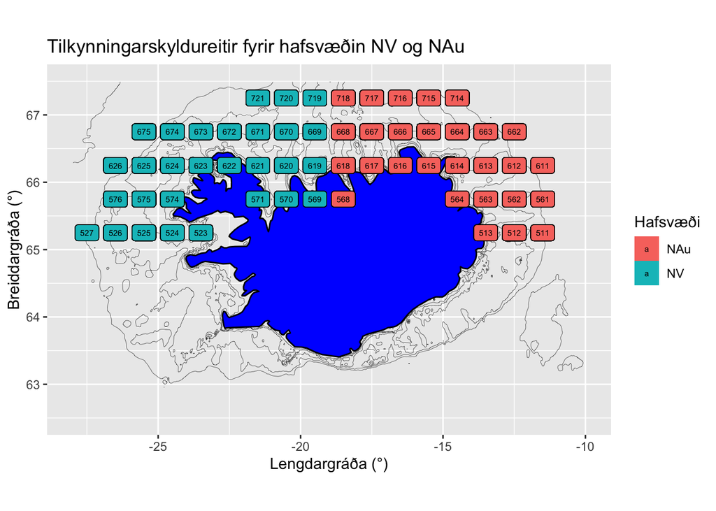

```r
reitirNV <- filter(ah, hafsvaedi == "NV")$reit
reitirNAu <- filter(ah, hafsvaedi == "NAu")$reit

xNV <- r2d(reitirNV)$lon
xNAu <- r2d(reitirNAu)$lon

yNV <- r2d(reitirNV)$lat
yNAu <- r2d(reitirNAu)$lat

kort +
  geom_label(
    aes(x = xNV, y = yNV, label = as.character(reitirNV), fill = "NV"),
    size = 2
  ) +
  geom_label(
    aes(x = xNAu, y = yNAu, label = as.character(reitirNAu), fill = "NAu"),
    size = 2
  ) +
  labs(
    fill = "Hafsvæði",
    title = "Tilkynningarskyldureitir fyrir hafsvæðin NV og NAu"
  )
```